# HW1

## Compare Sigmoid Function with ReLU

Ref: https://deepai.org/machine-learning-glossary-and-terms/sigmoid-function

### What is Sigmoid Function?

A Sigmoid Function 是一個具有S形狀曲線的數學函數，常見的 sigmoid function 像是 logistic function, hyperbolic tangent, arctangent.  
而在機器學習的領域裡， sigmoid function 通常使用 logistic function, 所以也稱為 logistic sigmoid function.  
所有 sigmoid function 都具有映射全部數線上的數值到一個很小的範圍，例如 (0,1)、(-1,1)，因此 sigmoid function 的一個功能是將實數轉換為一個可以解釋機率的數值  
最常廣泛使用的 sigmoid function 是 logistic function, 其映射任意實數到(0,1)， 因為這個特性在深度學習領域被用來當作人工神經網路的激活函數(activation function)  
而當 sigmoid function 放在機器學習模型的最後一層時可以把模型的輸出轉換成機率分數，如此一來可以更好的解釋以及操作模型的輸出  
Sigmoid function 是邏輯回歸模型中重要的一部份。邏輯回歸是對二類分類的線性回歸的修改版，將一個或多個實際數值的輸入轉換成機率，像是消費者購買產品的機率。

#### Sigmoid Function Formula

所有 sigmoid 函數都是 monotonic(單調)且有鐘形的第一導數，下圖為 sigmoid function， 可以看到具有基本的 S 形狀

```
<function matplotlib.pyplot.show(close=None, block=None)>
```

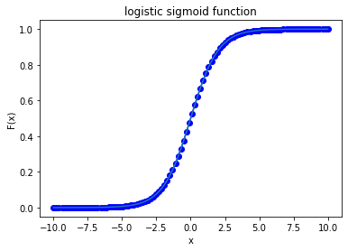

```python
from scipy.special import expit
import matplotlib.pyplot as plt
import numpy as np

# def range of x-values
x = np.linspace(-10, 10 ,100)

# calculate sigmoid function for each x-value
y = expit(x)

# create plot
plt.title('logistic sigmoid function')
plt.plot(x, y, color = 'blue', marker = "o")
plt.plot(x,y)
plt.xlabel('x')
plt.ylabel('F(x)')
plt.show
```

#### Hyperbolic Tangent Function Formula

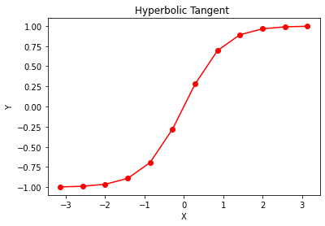

```python
in_array = np.linspace(-np.pi, np.pi, 12)
out_array = np.tanh(in_array)

plt.plot(in_array, out_array, color = 'red', marker = "o")
plt.title("Hyperbolic Tangent ")
plt.xlabel("X")
plt.ylabel("Y")
plt.show()
```

#### Arctangent Function Formula

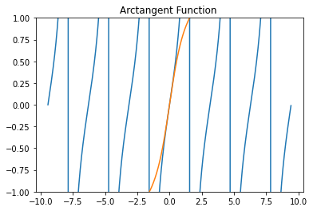

```python
x = np.arange(-3*np.pi, 3*np.pi, step = 0.02)

plt.ylim(-1,1)
tan = np.tan(x)
arctan = np.arctan(x)

plt.title('Arctangent Function ')
plt.plot(x,tan)
plt.plot(x,arctan)
```

#### Summary of three sigmoid functions

| Sigmoid function | Logistic function | Hyperbolic Tangent function | Arctangent Function |
| --- | --- | --- | --- |
| Value in the limit x →-∞ | 0 | -1 | -π/2 |
| Value at x = 0 | 0.5 | 0 | 0 |
| Value in the limit x →∞ | 1 | 1 | π/2 |
| Converges | Fast | Very fast | Very slow |

### What is Relu(rectified linear unit)?

Relu 是一個非線性的激活函數，用於多層神經網路或是深度神經網路，函數可以用下面方程式表示

$$ f(x) = max(0,x) \tag{1}$$

### The purpose of Relu AKA Compare Sigmoid Function with Relu

一般來說，一些盛行的非線性激活函數，像是 sigmoid function(logistic) 或是 hyperbolic tangent ，都是用在神經網路去得到激活函數的值去對應到每一個神經元。  
而最近 Relu function 被用來計算傳統神經網路或深度神經網路 paradigms(範例)中的激活值  
Relu 取代 Sigmoid 和 Hyperbolic tangent 的理由如下 :